# Group contributions to OSM

Women participation advocates

Users who have disclosed on their profiles “This user pledges to advocate for the participation of more women and girls in the OSM community”

# users

10

Mean account age (years)

13.37

# users with changesets

9

# users with diary notes

9

# users with wiki edits

7

**Account Age**

[interactive chart not shown]

**Map changesets**

[interactive chart not shown]

**Map Activity**

[interactive chart not shown]

**Comments Logged**

[interactive chart not shown]

**Diary Activity**

[interactive chart not shown]

**Trace Activity**

[interactive chart not shown]

**Contributions per type**

[interactive chart not shown]

**Contributions per hour**

[output not shown]

# users with changesets

9

# changesets

900

changesets/day

0.25

Where do they contribute?

[interactive chart not shown]

When do they contribute?

[interactive chart not shown]

**Changesets and size**

[interactive chart not shown]

**Tab 2**

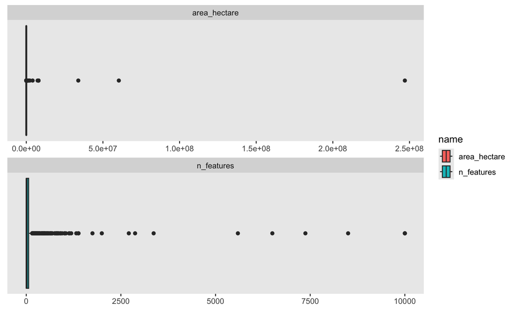

**Most Used keys**

[interactive chart not shown]

**Hashtags used**

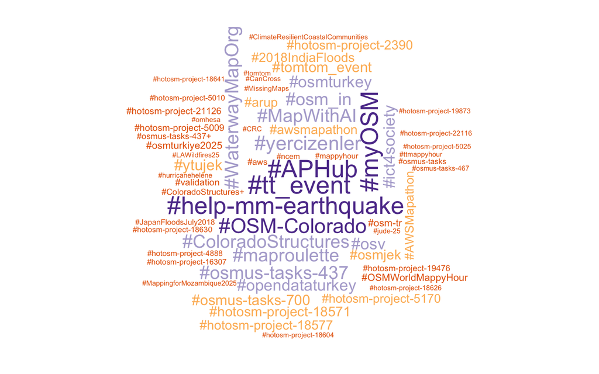

**Comments**

| bigram | n |
| --- | --- |
| osmus tasks | 81 |
| hotosm project | 74 |
| bus station | 46 |
| add public_transport | 45 |
| public_transport stop_area | 45 |
| retrace bus | 45 |
| adding buildings | 44 |
| add addresses | 37 |
| 726 add | 36 |
| county wa | 36 |
| eastern lincoln | 36 |
| lincoln county | 36 |
| tasks 726 | 36 |
| refugee camp | 34 |
| natural features | 31 |

**Most Used keys 2**

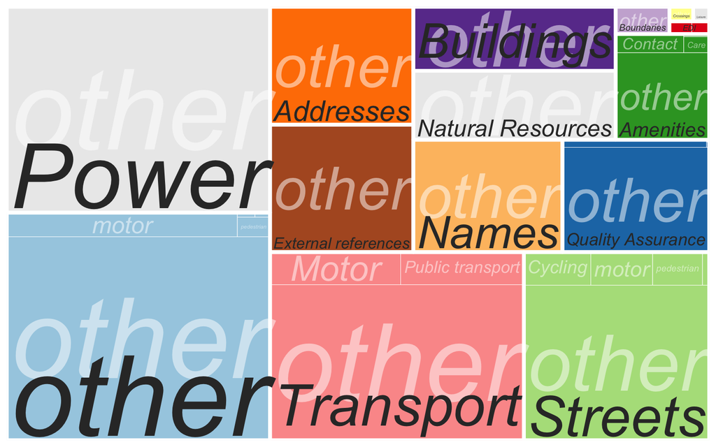

**Sources of information**

[interactive chart not shown]

**Software used**

[interactive chart not shown]

**Type of changesets**

[interactive chart not shown]

**Language**

[interactive chart not shown]

# users with wiki edits

total additions

2384.58

total deletions

-436.77

# of new pages created

21

When do they contribute?

[interactive chart not shown]

Written words by language

[interactive chart not shown]

Wiki changes and size

[interactive chart not shown]

Top 15 contributed wiki pages

[interactive chart not shown]

# users with diary entries

9

Wordcount based on titles

# users with map notes

8

# of notes

3,054

# of notes/user

381.75

Wordcout based on notes contents

# users with gpx traces

7

Total traces by country

This dashboard is a proof of concept that displays how a group of users contribute to OpenStreetMap with special consideration to EDI issues. That means, for example, that this dashboard recognises different types of contributions and all data shown has been anonymised.

This dashboard is a result of a codesign process with members of [Geochicas](https://wiki.openstreetmap.org/wiki/LatAm/Groups/GeoChicas) and the [Centre for Interdisciplinary Methodologies](https://warwick.ac.uk/cim) at the University of Warwick, and is inspired by Pascal Neis’ great [HDYC](https://hdyc.neis-one.org/), but with notable important differences:

- It displays how certain groups of users contribute to OSM, without revealing who their members are. For the purposes of this dashboard, a group is a number of users that have a shared interests who self-report as members of a group.
- It recognises that there are different ways of contributing to OSM beyond map contributions (e.g. wiki edits, user diaries…). As such, it incorporates data from different sources (see below).
- It is opensource: you can see the code (and contribute to it!) in [this GitHub repository](https://github.com/WarwickCIM/OSMdashboard).
- It is self-hosted (for now! -keep tuned), meaning that data stays in your computer.
- It is way slower!

Data Sources

- OpenStreetMap API (via [`{osmapiR})`](https://docs.ropensci.org/osmapiR/index.html))
- OpenStreetMap Wiki API
- OpenStreetMap User profiles

Acknowledgements

How to cite